# Course Project

Yanan

October 14, 2017

## 1. Project Summary

This is the final course project of the practical machine learning course on coursera. The goal of this project is to predict the manner in which the test subjects did the exercise, which is the outcome recoded in the `classe` variable in the data set. The activity has 5 manners labeled from `A` through `E`. By using regression analysis, we report a model based on the ranomd foreset algorithm to predict the manners in the test dataset. For more background information, please find visit the link: http://groupware.les.inf.puc-rio.br/har.

## 2. Exploratory Data Analysis

### 2.1 Loading R Packages

First we load the necessary libraries for regression models and plot etc.

```r
library(knitr)
library(caret)
library(randomForest)
library(e1071)
library(dplyr)
library(ggplot2)
library(ggcorrplot)
```

### 2.2 Data Loading

First we check if the required datasets exist. If not, we download them from the website and then read them with `read.csv` command.

```r
trainFile <- "pml-training.csv"
testFile <- "pml-testing.csv"
if (!file.exists(trainFile)){
        trainURL <- "https://d396qusza40orc.cloudfront.net/predmachlearn/pml-training.csv"
        download.file(trainURL, destfile = trainFile)
}
if (!file.exists(testFile)){
        testURL  <- "https://d396qusza40orc.cloudfront.net/predmachlearn/pml-testing.csv"
        download.file(trainURL, destfile = testFile)
}
train <- read.csv(trainFile)
test <- read.csv(testFile)
```

### 2.3 Data Clening

We first do some quick look at the data set. There appears to be 160 variables and a huge amount of records. Thus we need to do some cleaning before we jump into the regression part.

```r
dim(train)
```

```
## [1] 19622   160
```

First step is to roughly look at the data and to remove the ID variables which don’t contribute to statistics. These are the first two columns, i.e. ID and username.

```r
head(train[, 1:8], 5)
```

```
##   X user_name raw_timestamp_part_1 raw_timestamp_part_2   cvtd_timestamp
## 1 1  carlitos           1323084231               788290 05/12/2011 11:23
## 2 2  carlitos           1323084231               808298 05/12/2011 11:23
## 3 3  carlitos           1323084231               820366 05/12/2011 11:23
## 4 4  carlitos           1323084232               120339 05/12/2011 11:23
## 5 5  carlitos           1323084232               196328 05/12/2011 11:23
##   new_window num_window roll_belt
## 1         no         11      1.41
## 2         no         11      1.41
## 3         no         11      1.42
## 4         no         12      1.48
## 5         no         12      1.48
```

```r
train <-  train[, -c(1, 2)]
test <-  test[, -c(1, 2)]
```

Then we remove remove time dependent variables which are not related to the goal of this project.

```r
time_index <- grep("time", names(train))
train <- train[, -time_index]
test <- test[, -time_index]
```

Finally, we remove most NA variables and variables with nearly zero variance. Because they affect little to regression analysis.

```r
NA_index <- sapply(train, function(x) {mean(!is.na(x))}) > 0.95
train <- train[, NA_index == TRUE]
test <- test[, NA_index == TRUE]

NZV <- nearZeroVar(train)
train <- train[, -NZV]
test <- test[, -NZV]
```

### 2.4 Correlation Plot

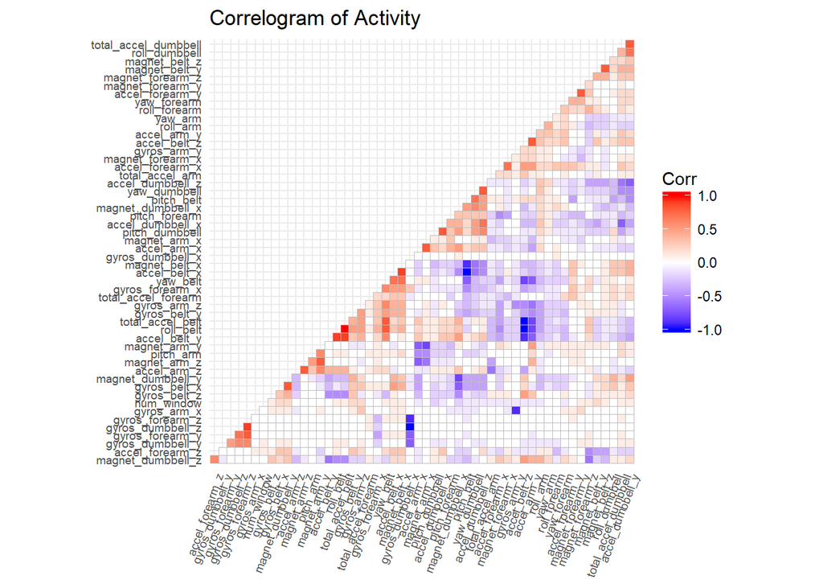

```r
corr <- round(cor(train[,-54]), 1)
g <- ggcorrplot(corr, hc.order = TRUE,
           type = "lower", tl.cex = 7, tl.srt = 70,
           title="Correlogram of Activity")
g
```

## 3. Regression Analysis

### 3.1 Data Partition

We split the train data again into train and test sets, with 80% in the training set.

```r
inTrain <- createDataPartition(y = train$classe, p = 0.8, list = FALSE)
trainSet <- train[inTrain, ]
testSet <- train[-inTrain, ]
print(data.frame("trainDim" = dim(trainSet), "testDim" = dim(testSet)))
```

```
##   trainDim testDim
## 1    15699    3923
## 2       54      54
```

### 3.2 Model Training

Now we choose three models for this dataset and compare which one works the best.

#### 3.2.1 Random Forest

We use the training function from the `randomForest` package. We print out the confusion matrix for both the training and the testing sets, as well as their acurracy of the prediction.

```r
set.seed(1111)
fit_rf <- randomForest(classe ~ ., data = trainSet)
pred_rf <- predict(fit_rf, newdata = testSet)

confusion_train_rf <- fit_rf$confusion
confusion_test_rf <- confusionMatrix(pred_rf, testSet$classe)$table
accuracy_train_rf <- sum(diag(confusion_train_rf))/sum(confusion_train_rf)
accuracy_test_rf <- sum(diag(confusion_test_rf))/sum(confusion_test_rf)

print(confusion_train_rf)
```

```
##      A    B    C    D    E  class.error
## A 4463    1    0    0    0 0.0002240143
## B    3 3033    2    0    0 0.0016458196
## C    0   10 2728    0    0 0.0036523009
## D    0    0   16 2556    1 0.0066070735
## E    0    0    0    5 2881 0.0017325017
```

```r
print(confusion_test_rf)
```

```
##           Reference
## Prediction    A    B    C    D    E
##          A 1116    1    0    0    0
##          B    0  758    6    0    0
##          C    0    0  678    1    0
##          D    0    0    0  642    0
##          E    0    0    0    0  721
```

```r
print(data.frame("train_rf" = accuracy_train_rf, "test_rf" = accuracy_test_rf))
```

```
##    train_rf   test_rf
## 1 0.9975786 0.9979607
```

#### 3.2.2 Support Vector Machine

We use the training function from the `e1071` package. Again We print out the confusion matrix for both the training and the testing sets, as well as their acurracy of the prediction.

```r
set.seed(1111)
fit_svm <- svm(classe ~ ., data = trainSet)
print(table(predict(fit_svm, trainSet[, -54]), trainSet[, 54]))
```

```
##
##        A    B    C    D    E
##   A 4439  171    5    3    0
##   B    3 2799   72    0    1
##   C   21   62 2639  223   31
##   D    0    2   19 2347   54
##   E    1    4    3    0 2800
```

```r
print(table(predict(fit_svm, testSet[, -54]), testSet[, 54]))
```

```
##
##        A    B    C    D    E
##   A 1106   33    2    0    0
##   B    2  712   29    0    1
##   C    8   13  647   54    7
##   D    0    0    5  587   13
##   E    0    1    1    2  700
```

```r
confusion_train_svm <- table(predict(fit_svm, trainSet[, -54]), trainSet[, 54])
confusion_test_svm <- table(predict(fit_svm, testSet[, -54]), testSet[, 54])
accuracy_train_svm <- sum(diag(confusion_train_svm))/sum(confusion_train_svm)
accuracy_test_svm <- sum(diag(confusion_test_svm))/sum(confusion_test_svm)

print(confusion_train_svm)
```

```
##
##        A    B    C    D    E
##   A 4439  171    5    3    0
##   B    3 2799   72    0    1
##   C   21   62 2639  223   31
##   D    0    2   19 2347   54
##   E    1    4    3    0 2800
```

```r
print(confusion_test_svm)
```

```
##
##        A    B    C    D    E
##   A 1106   33    2    0    0
##   B    2  712   29    0    1
##   C    8   13  647   54    7
##   D    0    0    5  587   13
##   E    0    1    1    2  700
```

```r
print(data.frame("train_svm" = accuracy_train_svm, "test_svm" = accuracy_test_svm))
```

```
##   train_svm  test_svm
## 1 0.9570036 0.9564109
```

#### 3.2.3 Generalized Boosted Model

Finally, we use the training function from the `caret` package. The gbm method in caret package is really slow.

```r
set.seed(1111)
control_gbm <- trainControl(method = "repeatedcv", number = 5, repeats = 1)
fit_gbm  <- train(classe ~ ., data=trainSet, method = "gbm",
                  trControl = control_gbm, verbose = FALSE)
pred_gbm <- predict(fit_gbm, newdata = testSet)

print(confusionMatrix(predict(fit_gbm, newdata = trainSet), trainSet$classe)$table)
```

```
##           Reference
## Prediction    A    B    C    D    E
##          A 4458   11    0    1    0
##          B    6 3015   17    9    6
##          C    0   12 2715   19    2
##          D    0    0    4 2542   16
##          E    0    0    2    2 2862
```

```r
print(confusionMatrix(pred_gbm, testSet$classe)$table)
```

```
##           Reference
## Prediction    A    B    C    D    E
##          A 1111    4    0    3    2
##          B    4  750    4    1    2
##          C    0    4  673    5    1
##          D    1    1    5  632   10
##          E    0    0    2    2  706
```

```r
confusion_train_gbm <- confusionMatrix(predict(fit_gbm), trainSet$classe)$table
confusion_test_gbm <- confusionMatrix(pred_gbm, testSet$classe)$table
accuracy_train_gbm <- sum(diag(confusion_train_gbm))/sum(confusion_train_gbm)
accuracy_test_gbm <- sum(diag(confusion_test_gbm))/sum(confusion_test_gbm)

print(confusion_train_gbm)
```

```
##           Reference
## Prediction    A    B    C    D    E
##          A 4458   11    0    1    0
##          B    6 3015   17    9    6
##          C    0   12 2715   19    2
##          D    0    0    4 2542   16
##          E    0    0    2    2 2862
```

```r
print(confusion_test_gbm)
```

```
##           Reference
## Prediction    A    B    C    D    E
##          A 1111    4    0    3    2
##          B    4  750    4    1    2
##          C    0    4  673    5    1
##          D    1    1    5  632   10
##          E    0    0    2    2  706
```

```r
print(data.frame("train_gbm" = accuracy_train_gbm, "test_gbm" = accuracy_test_gbm))
```

```
##   train_gbm  test_gbm
## 1 0.9931843 0.9869997
```

#### 3.2.4 Model Comparison

Finally, we compare the accuracy of the proposed models. The random forest method performed the best fitting, followed by generalized boosted model and support vector machine. Thus we will use random forest model to predict the test set in the next section.

```r
compare <- data.frame("rf" = c(accuracy_train_rf, accuracy_test_rf),
                      "svm" = c(accuracy_train_svm, accuracy_test_svm),
                      "gbm" = c(accuracy_train_gbm, accuracy_test_gbm))
rownames(compare) <- c("trainSet", "testSet")
print(compare)
```

```
##                 rf       svm       gbm
## trainSet 0.9975786 0.9570036 0.9931843
## testSet  0.9979607 0.9564109 0.9869997
```

## 4. Prediction

Finally we do prediction using the random forest model on the test data and use the output to fill in the quiz.

```r
pred_test = predict(fit_rf, newdata = test)
print(pred_test)
```

```
##  1  2  3  4  5  6  7  8  9 10 11 12 13 14 15 16 17 18 19 20
##  B  A  B  A  A  E  D  B  A  A  B  C  B  A  E  E  A  B  B  B
## Levels: A B C D E
```